# make up#1

paradise nxumalo 2020 801 63

2023-04-10

```r
rm(list = ls())
library(LearnEDAfunctions)
library(tidyverse)
library(reshape2)
library(aplpack)
library(vcd)
```

```r
library(ggplot2)
library(twoway)
library(car)
salaries.data <- read.csv("C:/Users/user/Desktop/sgele/YEAR III/Data Warehousing and Mining/PROJECTS/Salaries.csv")
salaries.data <- na.omit(salaries.data)
head(salaries.data)
```

```
##   X      rank discipline yrs.since.phd yrs.service  sex salary
## 1 1      Prof          B            19          18 Male 139750
## 2 2      Prof          B            20          16 Male 173200
## 3 3  AsstProf          B             4           3 Male  79750
## 4 4      Prof          B            45          39 Male 115000
## 5 5      Prof          B            40          41 Male 141500
## 6 6 AssocProf          B             6           6 Male  97000
```

```r
for (rank in unique(salaries.data$rank)) {
  print(paste0("rank: ",rank))
  print(stem.leaf(salaries.data[salaries.data$rank == rank, ]$salary))
}
```

```
## [1] "rank: Prof"
## 1 | 2: represents 12000
##  leaf unit: 1000
##             n: 266
##     1     5 | 7
##     2     6 | 7
##     6     7 | 2678
##    14     8 | 14788899
##    37     9 | 01112223333445666778899
##    89    10 | 0001111111222233333344445555556666677777778888999999
##   124    11 | 01111122333344444555566777778899999
##   (32)   12 | 00112222234444556666667788888999
##   110    13 | 0112223334444444556667778899
##    82    14 | 001122233444455555666677888
##    55    15 | 000000011111222335556
```

[output cut: 155 more lines]

> > A stem and leaf plot of the raw data grouped by the rank shows us a huge right skew on the rank of ‘Prof’. The rank of AsstProf and AssocProf both show a somewhat symmetrical display thought not perfectly.

```r
for (rank in unique(salaries.data$rank)) {
  print(paste0("rank: ",rank))
  print(fivenum(salaries.data[salaries.data$rank == rank, ]$salary))
}
```

```
## [1] "rank: Prof"
## [1]  57800.0 105890.0 123321.5 145098.0 231545.0
## [1] "rank: AsstProf"
## [1] 63100.0 74000.0 79800.0 88597.5 97032.0
## [1] "rank: AssocProf"
## [1]  62884.0  82350.0  95626.5 104331.5 126431.0
```

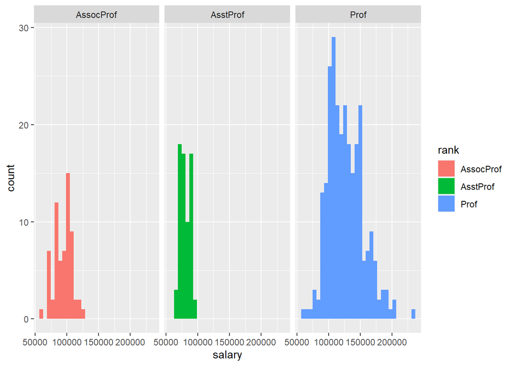

```r
ggplot(salaries.data, aes(x =  salary,fill =  rank))+
  geom_histogram()+facet_wrap(~rank)
```

> > Looking at the histogram further confirms that our ranks are right skewed with the strongest skew seen on the rank if Prof

```r
new.salaries.data <- salaries.data[, c(2,4,5,7)]

new.salaries.data %>%
  group_by(rank) %>%
  summarise_all(sum) %>%
  data.frame() -> salaries.dataz

head(salaries.dataz)
```

```
##        rank yrs.since.phd yrs.service   salary
## 1 AssocProf           989         765  6008092
## 2  AsstProf           342         159  5411991
## 3      Prof          7528        6069 33721381
```

```r
(salariess <- data.frame(salaries.dataz[,-1], row.names = salaries.dataz[,1]))
```

```
##           yrs.since.phd yrs.service   salary
## AssocProf           989         765  6008092
## AsstProf            342         159  5411991
## Prof               7528        6069 33721381
```

```r
# Median polish
(additive.fit <- medpolish(log(salariess)))
```

```
## 1: 1.81253
## Final: 1.81253
```

```
##
## Median Polish Results (Dataset: "log(salariess)")
##
## Overall: 6.896694
##
## Row Effects:
## AssocProf  AsstProf      Prof
##  0.000000 -1.061884  2.029690
##
## Column Effects:
## yrs.since.phd   yrs.service        salary
##     0.0000000    -0.2568185     8.7119235
##
## Residuals:
##           yrs.since.phd yrs.service   salary
## AssocProf             0    0.000000  0.00000
## AsstProf              0   -0.509088  0.95739
## Prof                  0    0.041383 -0.30467
```

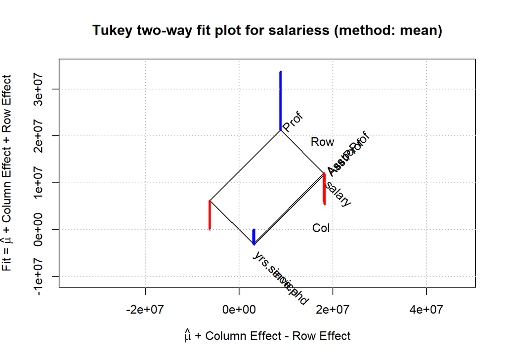

```r
plot(twoway(salariess))
grid(col = "#bbbbbb", lwd = 1.4)
```

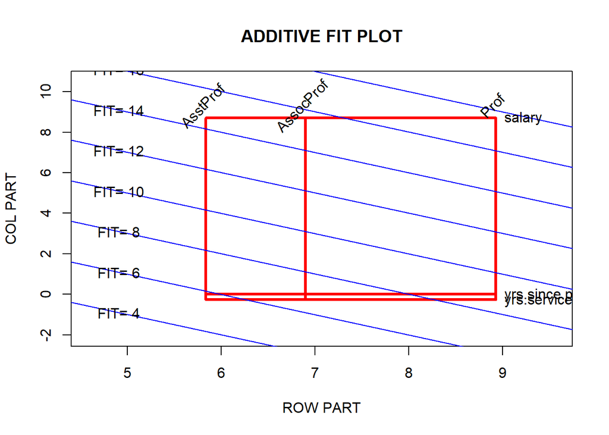

```r
##############
# Additive fit plot
Row.Part <- with(additive.fit, row + overall)
Col.Part <- additive.fit$col
plot2way(Row.Part, Col.Part,
         dimnames(salariess)[[1]], dimnames(salariess)[[2]])
```

> > Fit is not the most attractive but this is hugely influenced by the huge gap in count between salary and the other two variables. As such, Assistant Professors that from both yrs.since.phd and yrs.service have a small FIT of about 4 to 6.This tells us that their salary is lower too. Professors are the ones that appear to get a high salary as they have the highest FIT

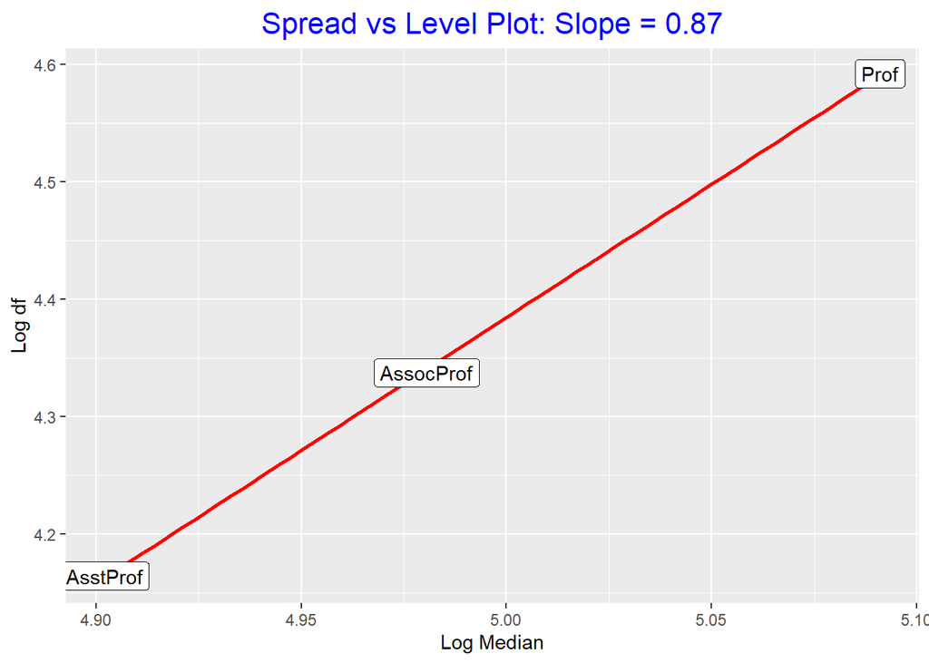

```
## # A tibble: 3 × 5
##   rank            M     df log.M log.df
##   <chr>       <dbl>  <dbl> <dbl>  <dbl>
## 1 AssocProf  95626. 21751.  4.98   4.34
## 2 AsstProf   79800  14598.  4.90   4.16
## 3 Prof      123322. 39105.  5.09   4.59
```

```r
spread_level_plot(salaries.data,salary,rank)
```

```r
(p <- 1-0.87)
```

```
## [1] 0.13
```

> > The spread level plot returns 0.87 and subtracting that value from 1 give us 0.13 which suggests a log transformation as the most approproate to reexpress our dataset.

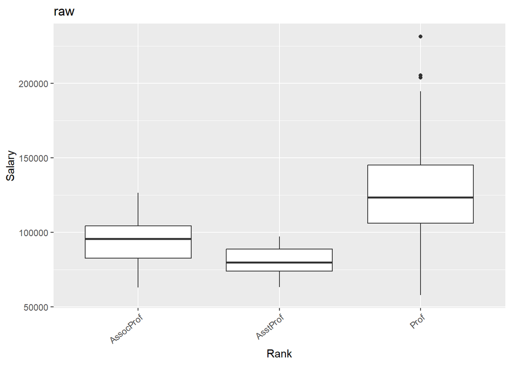

```r
framed.datas <- data.frame(rank = salaries.data$rank,
                           salary =salaries.data$salary)
#################################
ggplot(framed.datas, aes(rank,salary))+
  geom_boxplot()+
  labs(title = 'raw',y = "Salary" ,x = "Rank" )+
  theme(axis.text.x = element_text(angle = 40,hjust = 1))
```

> > The boxplots have visibly uneven spreads making it impossible to compare.

```r
midds <- lval(framed.datas$salary)
midds$mids
```

```
## [1] 107300.0 112592.5 115240.0 120157.2 124400.0 129304.5 129350.0 133871.0
## [9] 144672.5
```

```r
lval_plus(framed.datas,salary,rank) %>%
  group_by(rank) %>%
  summarise(rank = unique(rank),
            Fence_LO = median(Fence_LO),
            Fence_HI = median (Fence_HI),
            Count_Outs = sum(OUT == TRUE),
            .groups = 'drop')
```

```
## # A tibble: 3 × 4
##   rank      Fence_LO Fence_HI Count_Outs
##   <chr>        <dbl>    <dbl>      <int>
## 1 AssocProf   49848.  136853.          0
## 2 AsstProf    52104.  110494.          0
## 3 Prof        47317.  203738.          3
```

> > The AssocProf and Asst ranks both have no outliers. Prof has 3 of them.

```r
lval_plus(salaries.data,salary,rank)[-c(2:3)]%>%
  group_by(rank)%>%
  filter(OUT == TRUE)%>%
  arrange(salary, .by_group = T)%>%
  select(c('rank','discipline','yrs.since.phd','yrs.service','sex','salary'))
```

```
## # A tibble: 3 × 6
## # Groups:   rank [1]
##   rank  discipline yrs.since.phd yrs.service sex   salary
##   <chr> <chr>              <int>       <int> <chr>  <int>
## 1 Prof  A                     29           7 Male  204000
## 2 Prof  A                     43          43 Male  205500
## 3 Prof  B                     38          38 Male  231545
```

> > The three outliers from the Prof rank Prof A Male with a salary of 204 000. The 2nd if Prof A Male earning a salary of 205 500 and lastly if Prof B Male earning 231 545 in salary.

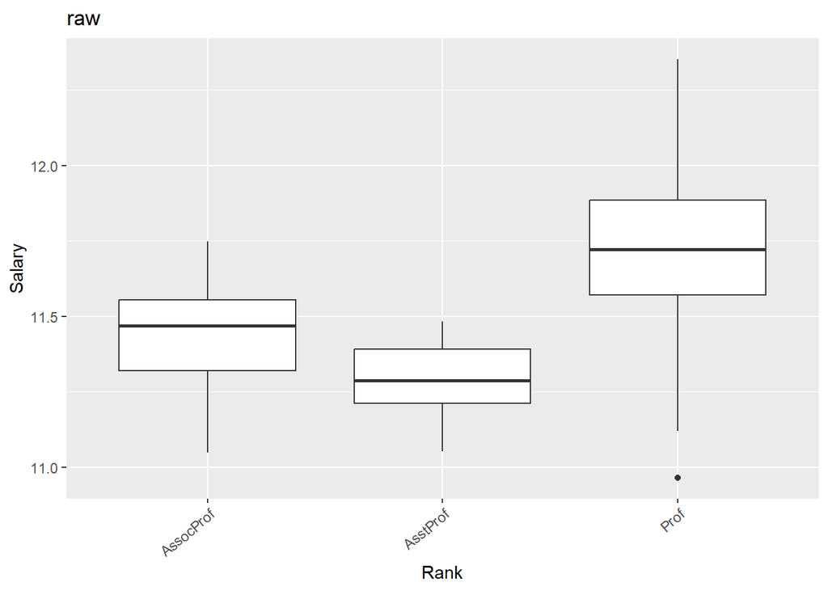

```r
framed.data <- data.frame(rank = salaries.data$rank,
                           salary =log(salaries.data$salary))

ggplot(framed.data, aes(rank,salary))+
  geom_boxplot()+
  labs(title = 'raw',y = "Salary" ,x = "Rank" )+
  theme(axis.text.x = element_text(angle = 40,hjust = 1))
```

```r
sort(salaries.data$salary)[1:10]
```

```
##  [1] 57800 62884 63100 63900 67559 68404 69200 69700 70000 70700
```

```r
max(salaries.data$salary)
```

```
## [1] 231545
```

```r
min(salaries.data$salary)
```

```
## [1] 57800
```

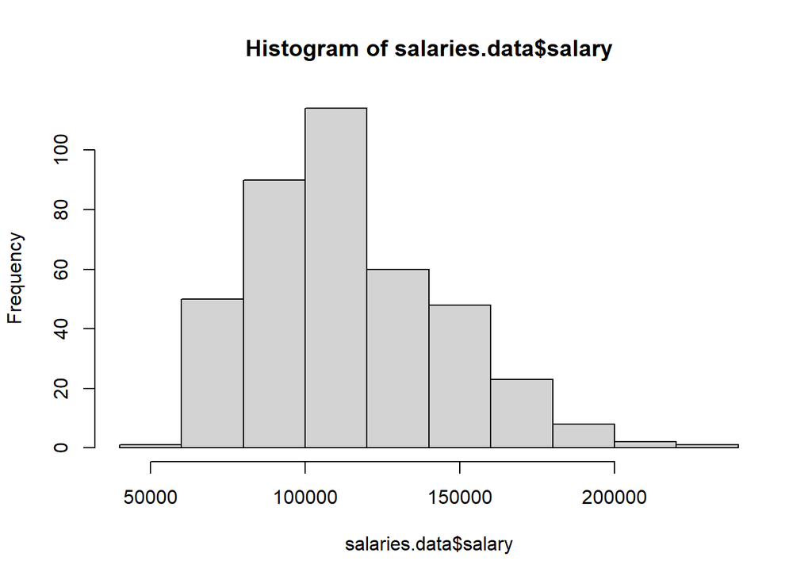

```r
h.bin <- hist(salaries.data$salary, plot = T)
```

```r
bins <- h.bin$breaks

(bin.mids <- (bins[-1] + bins[-length(bins)]) / 2)
```

```
##  [1]  50000  70000  90000 110000 130000 150000 170000 190000 210000 230000
```

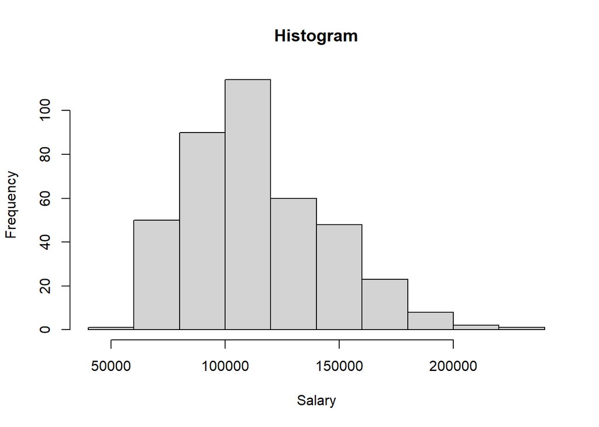

```
## $breaks
##  [1]  40000  60000  80000 100000 120000 140000 160000 180000 200000 220000
## [11] 240000
##
## $counts
##  [1]   1  50  90 114  60  48  23   8   2   1
##
## $density
##  [1] 1.259446e-07 6.297229e-06 1.133501e-05 1.435768e-05 7.556675e-06
##  [6] 6.045340e-06 2.896725e-06 1.007557e-06 2.518892e-07 1.259446e-07
##
## $mids
##  [1]  50000  70000  90000 110000 130000 150000 170000 190000 210000 230000
##
## $xname
## [1] "salary"
##
## $equidist
## [1] TRUE
##
## attr(,"class")
## [1] "histogram"
```

```r
(h <- with(salaries.data,hist(salary, breaks = bins, xlab = "Salary", main = "Histogram")))
```

```r
data.frame(Mid=h$mids, Count=h$counts, Roots=sqrt(h$counts))
```

```
##       Mid Count     Roots
## 1   50000     1  1.000000
## 2   70000    50  7.071068
## 3   90000    90  9.486833
## 4  110000   114 10.677078
## 5  130000    60  7.745967
## 6  150000    48  6.928203
## 7  170000    23  4.795832
## 8  190000     8  2.828427
## 9  210000     2  1.414214
## 10 230000     1  1.000000
```

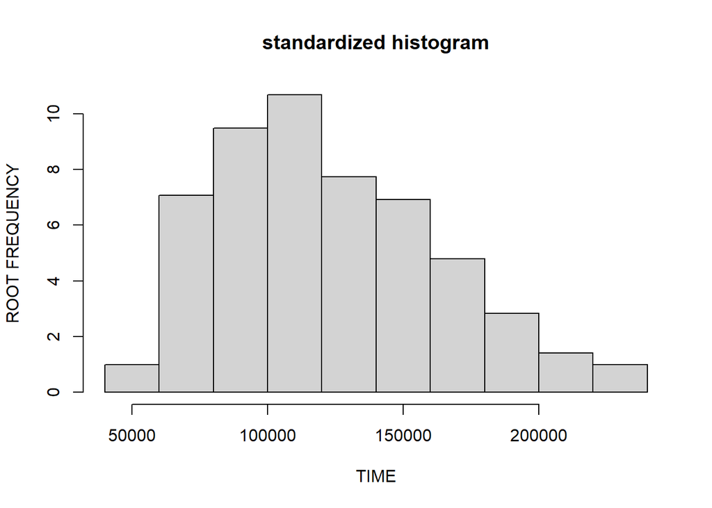

```r
h$counts <- sqrt(h$counts)
plot(h, xlab = "TIME", ylab = "ROOT FREQUENCY", main = "standardized histogram")
```

```r
(fl.u <- fivenum(salaries.data$salary)[c(2,4)])
```

```
## [1]  91000 134185
```

```r
g.mean <- sum(fl.u)/2
g.sd <- diff(fl.u)/1.349

median <- median(salaries.data$salary)
df <- IQR(salaries.data$salary)

s <- fit.gaussian(salaries.data$salary, bins, median, df)
s <- fit.gaussian(salaries.data$salary, bins, g.mean, g.sd)

options(digits=4)
(data <- data.frame(Mid=bin.mids, d=s$counts, sqrt.d=sqrt(s$counts),
                    Prob=s$probs, e=s$expected, sqrt.e=sqrt(s$expected),
                    Residual=s$residual))
```

```
##       Mid   d sqrt.d      Prob       e sqrt.e Residual
## 1   50000   1  1.000 0.0385289 15.2960 3.9110  -2.9110
## 2   70000  50  7.071 0.1041067 41.3303 6.4289   0.6422
## 3   90000  90  9.487 0.1927148 76.5078 8.7469   0.7400
## 4  110000 114 10.677 0.2444688 97.0541 9.8516   0.8255
## 5  130000  60  7.746 0.2125465 84.3810 9.1859  -1.4399
## 6  150000  48  6.928 0.1266417 50.2768 7.0906  -0.1624
## 7  170000  23  4.796 0.0516993 20.5246 4.5304   0.2654
## 8  190000   8  2.828 0.0144544  5.7384 2.3955   0.4329
## 9  210000   2  1.414 0.0027662  1.0982 1.0479   0.3663
## 10 230000   1  1.000 0.0003621  0.1438 0.3792   0.6208
```

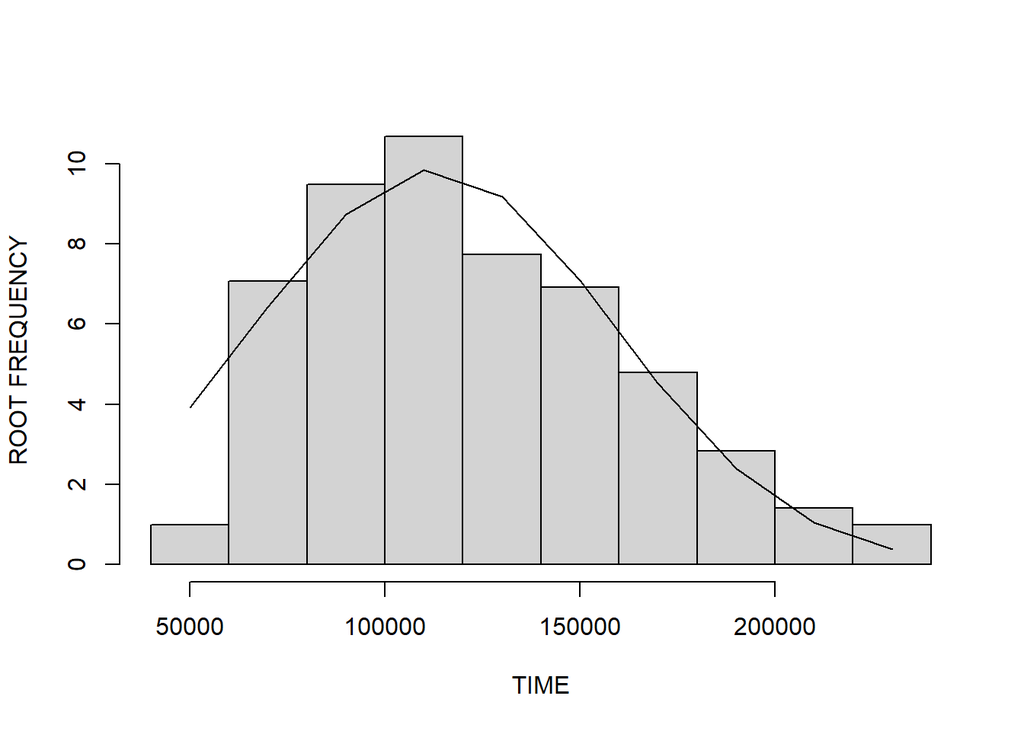

```r
plot(h, xlab = "TIME", ylab = "ROOT FREQUENCY", main = "")

lines(bin.mids, sqrt(s$expected))
```

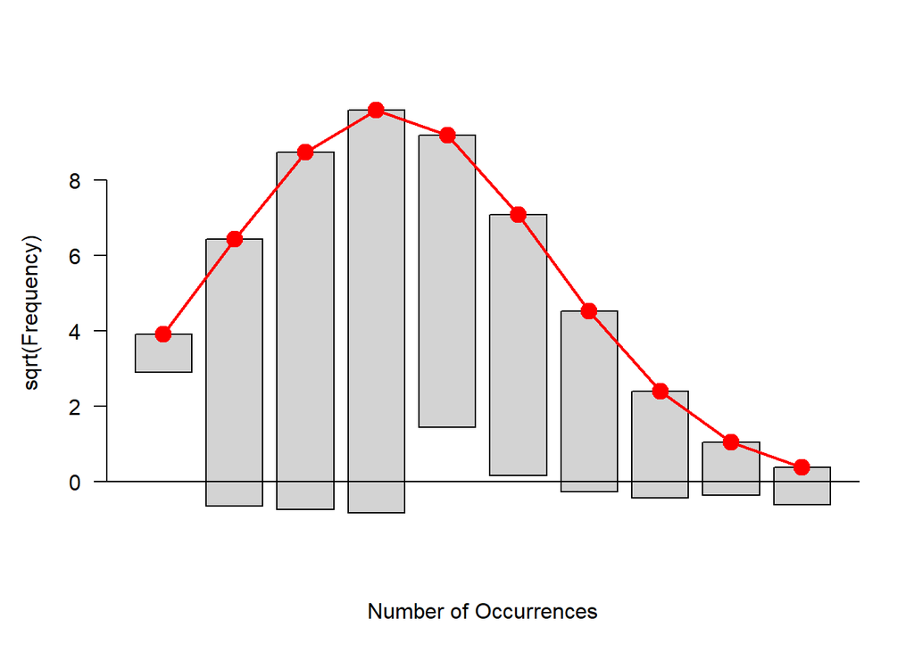

```r
rootogram(s$counts, s$expected)
```

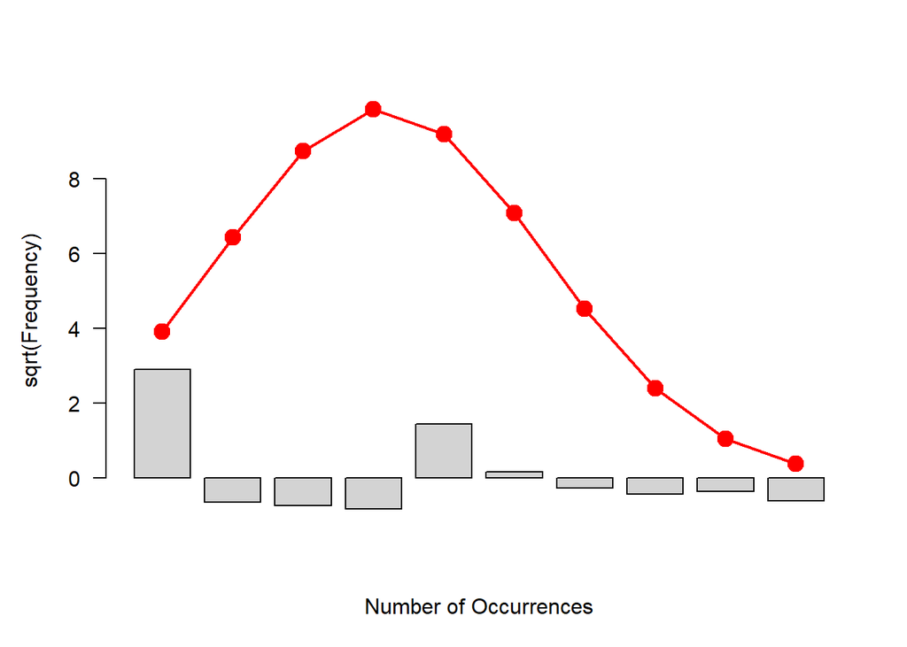

```r
rootogram(s$counts, s$expected, type = 'deviation')
```

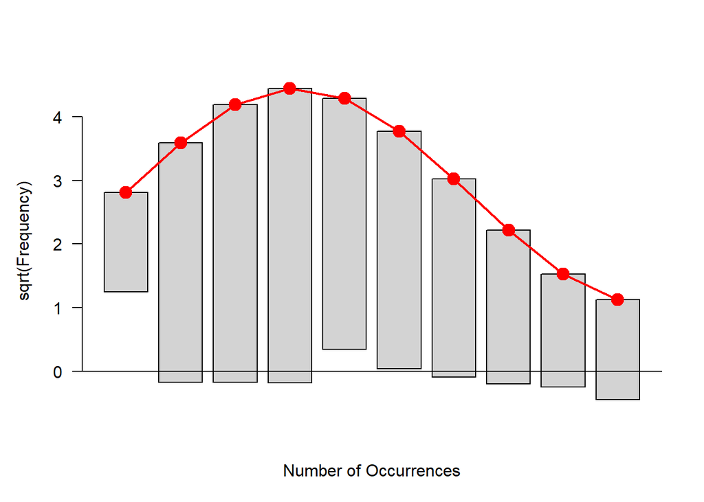

```r
data$drr <- with(data, sqrt(2 + 4*d) - sqrt(1 + 4*e))

with(data, rootogram(sqrt(2 + 4*d), sqrt(1 + 4*e)))
```

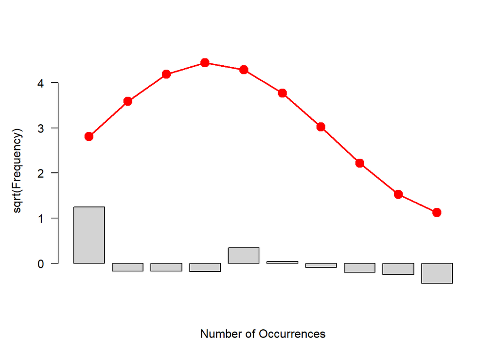

```r
with(data, rootogram(sqrt(2 + 4*d), sqrt(1 + 4*e), type = 'deviation'))
```

> > The rootogram on the salary is not the best fit thought its not looking too bad.This because the overall skew of the salary is right skewed hence a rootogram cannot fit the perfectly normal curve.Its worth tranforming though to see if it can be improved.

```r
salaries.data<- data.frame(rank = salaries.data$rank,discipline = salaries.data$discipline,
                           yrs.since.phd= salaries.data$yrs.since.phd,yrs.service = salaries.data$yrs.service,
                           sex = salaries.data$sex, salary = salaries.data$salary, log.salary = log(salaries.data$salary))

sort(salaries.data$log.salary)[1:10]
```

```
##  [1] 10.96 11.05 11.05 11.07 11.12 11.13 11.14 11.15 11.16 11.17
```

```r
max(salaries.data$log.salary)
```

```
## [1] 12.35
```

```r
min(salaries.data$log.salary)
```

```
## [1] 10.96
```

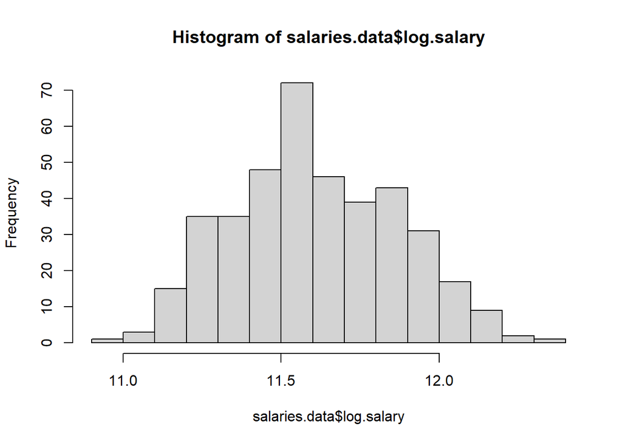

```r
h.bin <- hist(salaries.data$log.salary, plot = T)
```

```r
bins <- h.bin$breaks

(bin.mids <- (bins[-1] + bins[-length(bins)]) / 2)
```

```
##  [1] 10.95 11.05 11.15 11.25 11.35 11.45 11.55 11.65 11.75 11.85 11.95 12.05
## [13] 12.15 12.25 12.35
```

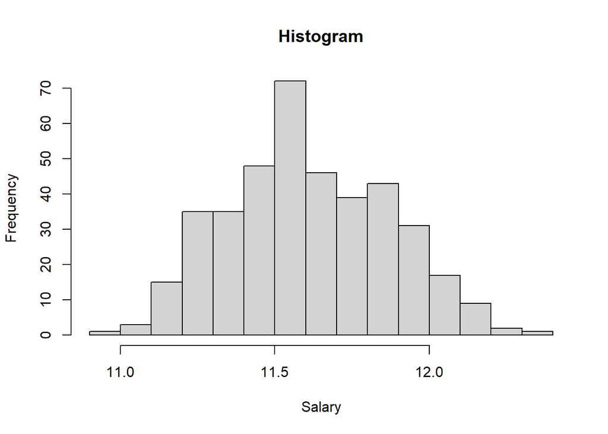

```
## $breaks
##  [1] 10.9 11.0 11.1 11.2 11.3 11.4 11.5 11.6 11.7 11.8 11.9 12.0 12.1 12.2 12.3
## [16] 12.4
##
## $counts
##  [1]  1  3 15 35 35 48 72 46 39 43 31 17  9  2  1
##
## $density
##  [1] 0.02519 0.07557 0.37783 0.88161 0.88161 1.20907 1.81360 1.15869 0.98237
## [10] 1.08312 0.78086 0.42821 0.22670 0.05038 0.02519
##
## $mids
##  [1] 10.95 11.05 11.15 11.25 11.35 11.45 11.55 11.65 11.75 11.85 11.95 12.05
## [13] 12.15 12.25 12.35
##
## $xname
## [1] "salaries.data$log.salary"
##
## $equidist
## [1] TRUE
##
## attr(,"class")
## [1] "histogram"
```

```r
(h <- hist(salaries.data$log.salary, breaks = bins, xlab = "Salary", main = "Histogram"))
```

```r
data.frame(Mid=h$mids, Count=h$counts, Roots=sqrt(h$counts))
```

```
##      Mid Count Roots
## 1  10.95     1 1.000
## 2  11.05     3 1.732
## 3  11.15    15 3.873
## 4  11.25    35 5.916
## 5  11.35    35 5.916
## 6  11.45    48 6.928
## 7  11.55    72 8.485
## 8  11.65    46 6.782
## 9  11.75    39 6.245
## 10 11.85    43 6.557
## 11 11.95    31 5.568
## 12 12.05    17 4.123
## 13 12.15     9 3.000
## 14 12.25     2 1.414
## 15 12.35     1 1.000
```

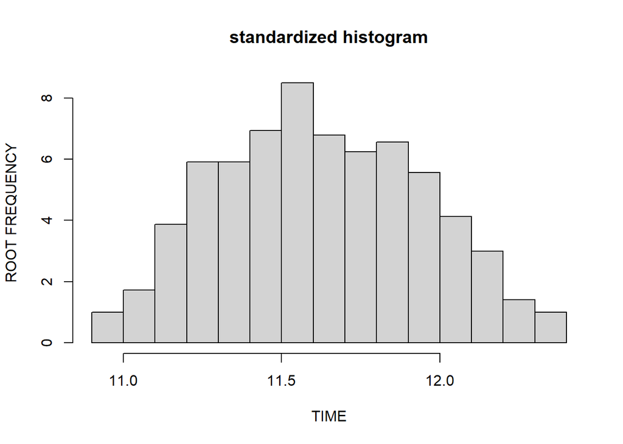

```r
h$counts <- sqrt(h$counts)
plot(h, xlab = "TIME", ylab = "ROOT FREQUENCY", main = "standardized histogram")
```

```r
# Gaussian Resistant measures
(fl.u <- fivenum(salaries.data$log.salary)[c(2,4)])
```

```
## [1] 11.42 11.81
```

```r
g.mean <- sum(fl.u)/2
g.sd <- diff(fl.u)/1.349

# Standard Resistant measures
median <- median(salaries.data$log.salary)
df <- IQR(salaries.data$log.salary)

s <- fit.gaussian(salaries.data$log.salary, bins, median, df)
s <- fit.gaussian(salaries.data$log.salary, bins, g.mean, g.sd)

options(digits=3)
(data <- data.frame(Mid=bin.mids, d=s$counts, sqrt.d=sqrt(s$counts),
                    Prob=s$probs, e=s$expected, sqrt.e=sqrt(s$expected),
                    Residual=s$residual))
```

```
##     Mid  d sqrt.d    Prob     e sqrt.e Residual
## 1  10.9  1   1.00 0.01000  3.97   1.99  -0.9925
## 2  11.1  3   1.73 0.02079  8.25   2.87  -1.1411
## 3  11.2 15   3.87 0.03837 15.23   3.90  -0.0298
## 4  11.2 35   5.92 0.06282 24.94   4.99   0.9221
## 5  11.4 35   5.92 0.09128 36.24   6.02  -0.1037
## 6  11.4 48   6.93 0.11770 46.73   6.84   0.0926
## 7  11.6 72   8.49 0.13467 53.47   7.31   1.1733
## 8  11.6 46   6.78 0.13675 54.29   7.37  -0.5858
## 9  11.8 39   6.24 0.12322 48.92   6.99  -0.7492
## 10 11.9 43   6.56 0.09853 39.12   6.25   0.3032
## 11 11.9 31   5.57 0.06991 27.76   5.27   0.2994
## 12 12.1 17   4.12 0.04402 17.48   4.18  -0.0575
## 13 12.2  9   3.00 0.02460  9.77   3.13  -0.1251
## 14 12.2  2   1.41 0.01220  4.84   2.20  -0.7864
## 15 12.4  1   1.00 0.00537  2.13   1.46  -0.4597
```

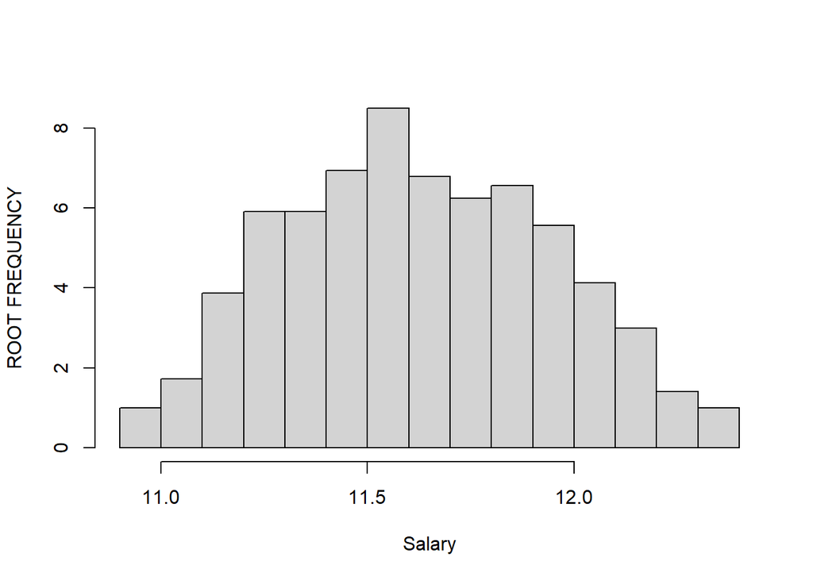

```r
plot(h, xlab = "Salary", ylab = "ROOT FREQUENCY", main = "")
```

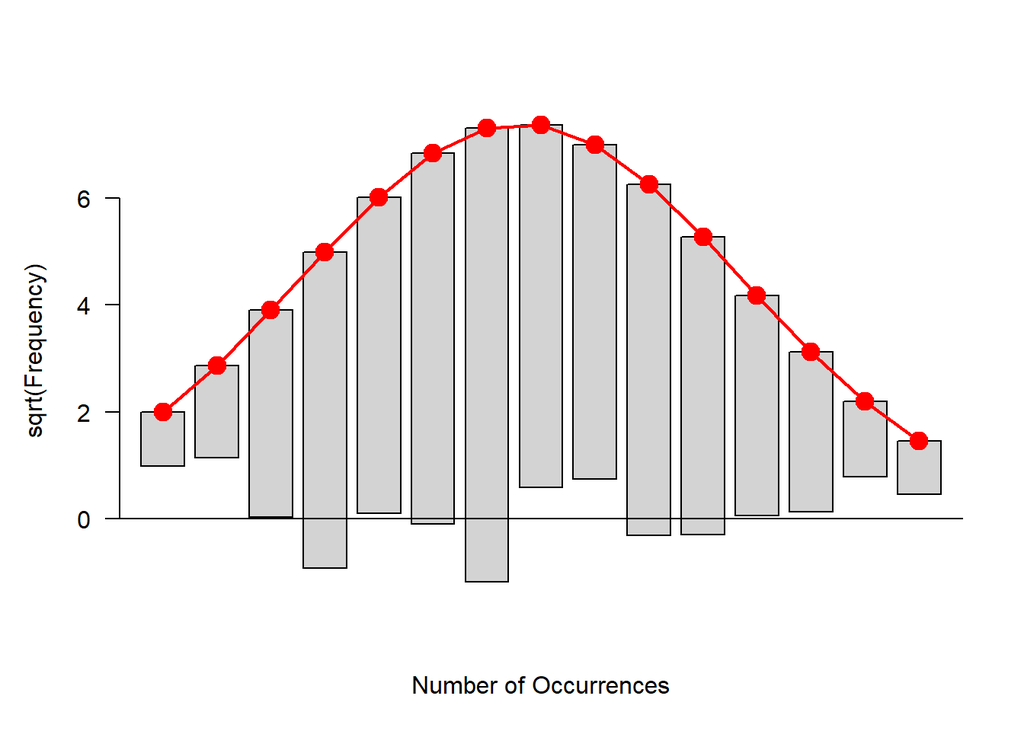

```r
rootogram(s$counts, s$expected)
```

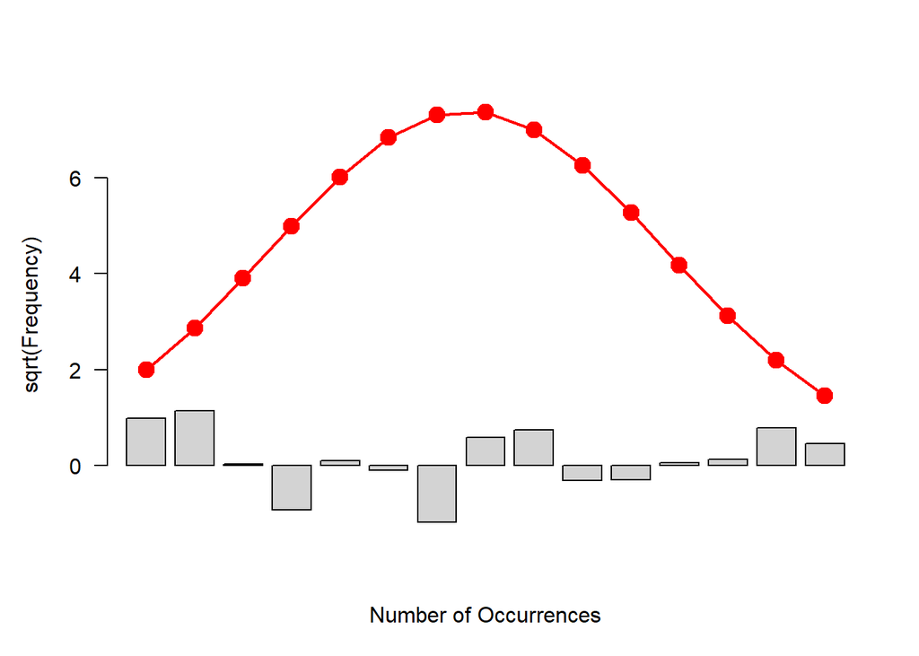

```r
rootogram(s$counts, s$expected, type = 'deviation')
```

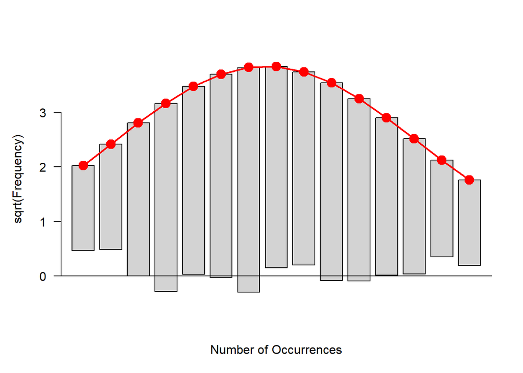

```r
data$drr <- with(data, sqrt(2 + 4*d) - sqrt(1 + 4*e))

# Alternative especially when bins have small counts
with(data, rootogram(sqrt(2 + 4*d), sqrt(1 + 4*e)))
```

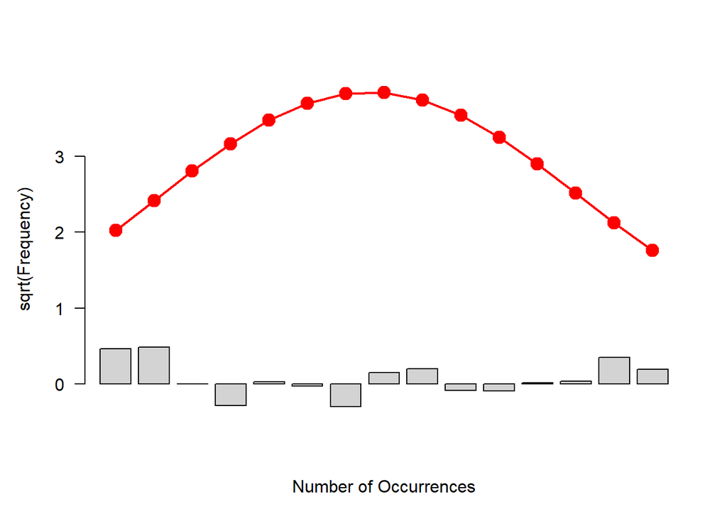

```r
with(data, rootogram(sqrt(2 + 4*d), sqrt(1 + 4*e), type = 'deviation'))
```

>>Here we have succesfully tranformed a set to be more symmetrical such that the nornal curves fits better. We also do not have significant over and underfits.

```r
lo.68 <- g.mean-g.sd
hi.68 <- g.mean + g.sd
(lo.68.percent <- exp(c(lo.68, hi.68)))
```

```
## [1]  82860 147367
```

```r
lo.95 <- g.mean-(2*g.sd)
hi.95 <- g.mean + (2*g.sd)
(lo.95.percent <- exp(c(lo.95, hi.95)))
```

```
## [1]  62132 196530
```

> > The middle 68% range corresponds to 82 860 and 147 367. The middle 95% range is 62 132 and 196 530.

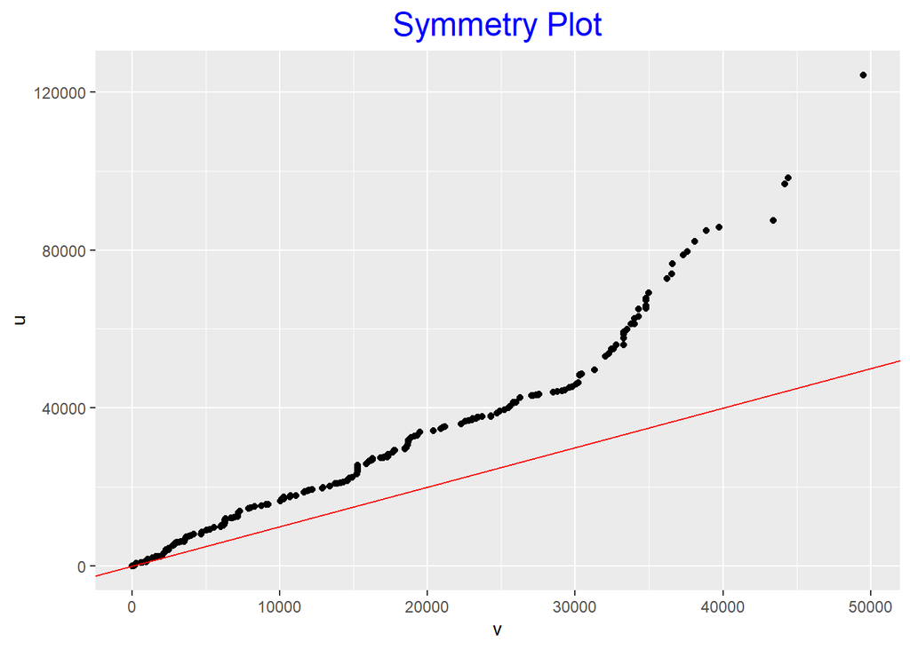

```r
symplot(salaries.data$salary)
```

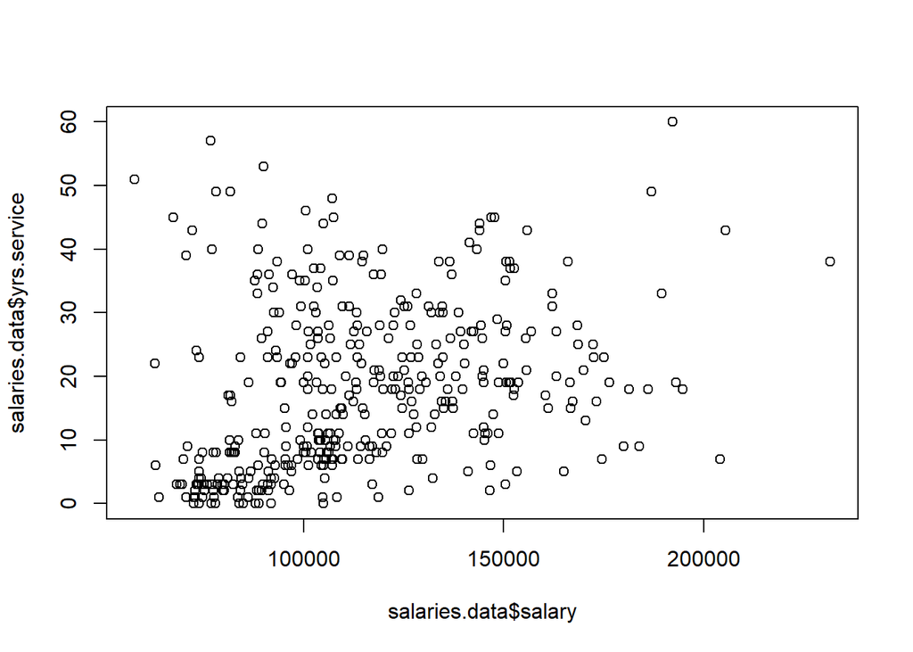

```r
plot(salaries.data$salary,salaries.data$yrs.service)
```

```r
head(salaries.data)
```

```
##        rank discipline yrs.since.phd yrs.service  sex salary log.salary
## 1      Prof          B            19          18 Male 139750       11.8
## 2      Prof          B            20          16 Male 173200       12.1
## 3  AsstProf          B             4           3 Male  79750       11.3
## 4      Prof          B            45          39 Male 115000       11.7
## 5      Prof          B            40          41 Male 141500       11.9
## 6 AssocProf          B             6           6 Male  97000       11.5
```

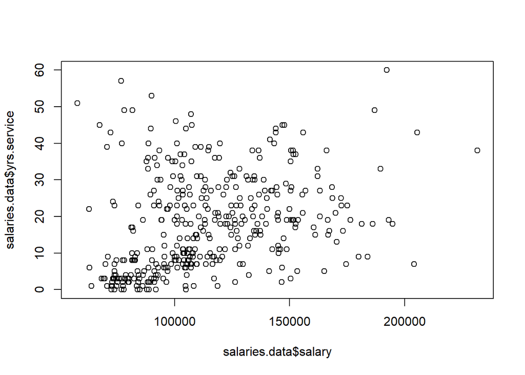

```r
plot(salaries.data$salary,salaries.data$yrs.service)
```

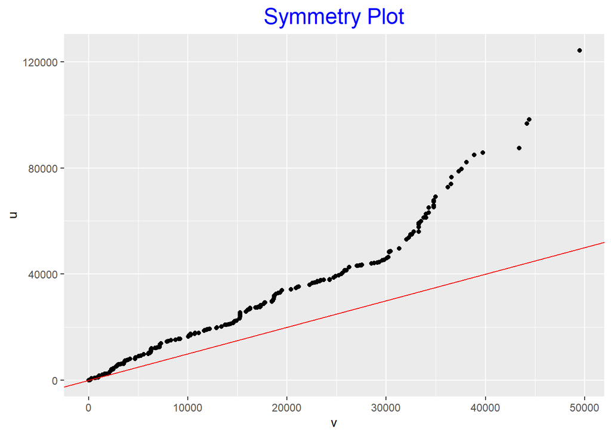

```r
symplot(salaries.data$salary)
```

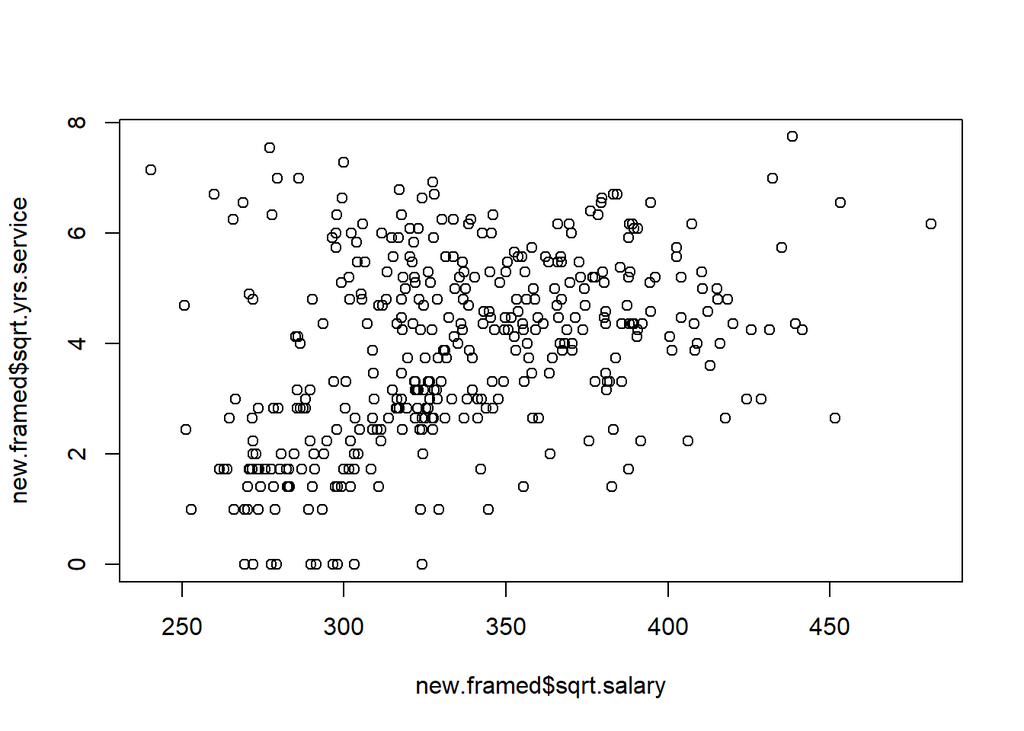

```r
new.framed <- data.frame(sqrt.yrs.service = sqrt(salaries.data$yrs.service),
                         sqrt.salary = sqrt(salaries.data$salary))
plot(new.framed$sqrt.salary,new.framed$sqrt.yrs.service)
```

```r
(sorted.datas <- new.framed[order(new.framed$sqrt.yrs.service, decreasing = T),])
```

```
##     sqrt.yrs.service sqrt.salary
## 331             7.75         438
## 132             7.55         277
## 195             7.28         300
## 283             7.14         240
## 126             7.00         280
## 286             7.00         286
## 351             7.00         432
## 277             6.93         327
## 280             6.78         317
## 8               6.71         384
## 72              6.71         383
## 262             6.71         328
## 318             6.71         260
## 269             6.63         299
```

[output cut: 383 more lines]

```r
sorted.datas$group <- as.numeric(cut_number(sorted.datas$sqrt.yrs.service, 3)) #dividing data into three groups
length(sorted.datas$sqrt.salary)
```

```
## [1] 397
```

```r
# Counts per group
(n1 <- nrow(sorted.datas[which(sorted.datas$group == 1),]))# which means where
```

```
## [1] 144
```

```r
(n2 <- nrow(sorted.datas[which(sorted.datas$group == 2),]))
```

```
## [1] 136
```

```r
(n3 <- nrow(sorted.datas[which(sorted.datas$group == 3),]))
```

```
## [1] 117
```

```r
# Find divisions between groups
t1 <- first(sorted.datas[which(sorted.datas$group == 1),
                              'sqrt.yrs.service'])

t2 <- first(sorted.datas[which(sorted.datas$group == 2),
                              'sqrt.yrs.service'])

# find (median x, median y) and put to one data frame
# summary.points <- data.frame(x=c(1.79, 1.87, 2.03),
#                        y=c(2.08, 2.14, 2.31))
(summary.points <- as.data.frame(
  rbind(
    sapply(sorted.datas[which(sorted.datas$group == 1),
                       1:2], 2, FUN = median),
    sapply(sorted.datas[which(sorted.datas$group == 2),
                       1:2], 2, FUN = median),
    sapply(sorted.datas[which(sorted.datas$group == 3),
                       1:2], 2, FUN = median) #2 means column
  )
)
)
```

```
##   sqrt.yrs.service sqrt.salary
## 1             2.00         302
## 2             4.24         350
## 3             5.74         345
```

```r
(slr.full <- lm(sqrt.salary ~ sqrt.yrs.service,
                data = new.framed))
```

```
##
## Call:
## lm(formula = sqrt.salary ~ sqrt.yrs.service, data = new.framed)
##
## Coefficients:
##      (Intercept)  sqrt.yrs.service
##            293.3              10.7
```

```r
(slr.resistant <- lm(sqrt.salary ~ sqrt.yrs.service,  summary.points))
```

```
##
## Call:
## lm(formula = sqrt.salary ~ sqrt.yrs.service, data = summary.points)
##
## Coefficients:
##      (Intercept)  sqrt.yrs.service
##            283.2              12.3
```

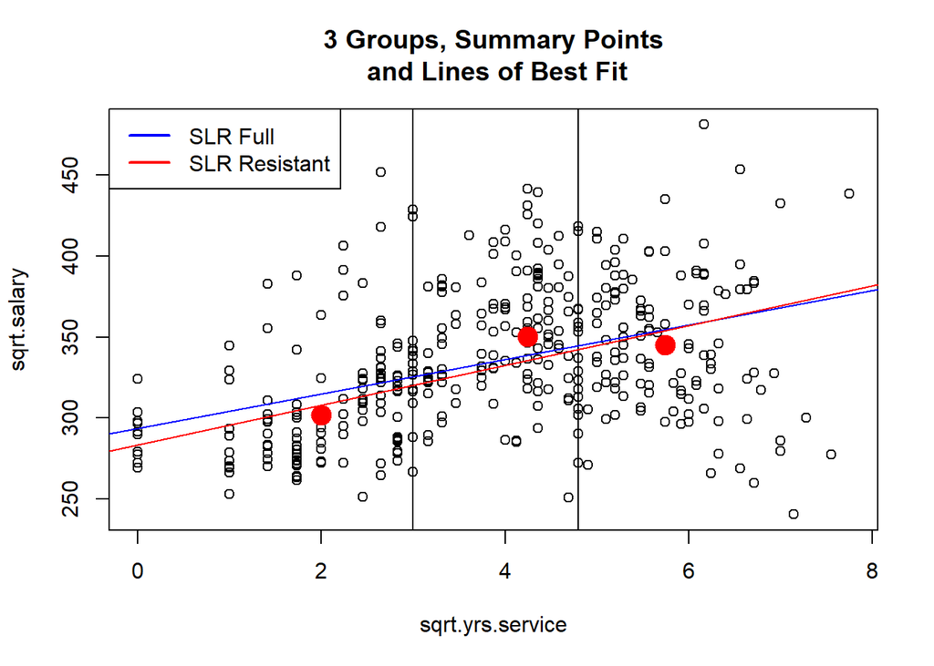

```r
#is rlm model from original data, will it be similar to resistant line
#r.resistant <-rlm(log.2000~log.1985, data = home.prices))




# View plot with 3rds and summary points
with(sorted.datas, plot(sqrt.yrs.service, sqrt.salary,
                       main="3 Groups, Summary Points\n and Lines of Best Fit"))
abline(v=t1)
abline(v=t2)
points(summary.points, cex=2, pch=19, col="red")

abline(slr.full, col = "blue")
abline(slr.resistant, col = "red")
legend("topleft", legend = c("SLR Full", "SLR Resistant"),
       col = c("blue", "red"), lwd=2)
```

```r
# Fitting a risistant line to data with rline
(myfit <- rline(sqrt.salary~sqrt.yrs.service, new.framed))
```

```
## $a
## [1] 332
##
## $b
## [1] 11.7
##
## $xC
## [1] 4
##
## $half.slope.ratio
## [1] -0.198
##
## $residual
##   [1]   39.0973   84.2711  -23.0280  -18.9909   16.2116   -2.3548   77.1385
##   [8]   20.8878    7.9129   24.4315   27.8951  -19.2295  -18.1362   -5.9257
```

[output cut: 61 more lines]

```r
FIT <- with(myfit, a + b * (new.framed$sqrt.salary - xC))
RESIDUAL <- myfit$residual
options(digits=4) # round everything to 4 digits
salaries.data <- data.frame(rank = salaries.data$rank,
           discipline = salaries.data$discipline,
           yrs.since.phd =  salaries.data$yrs.since.phd,
          yrs.service = salaries.data$yrs.service,
          sex = salaries.data$sex,
          salary = salaries.data$salary,
          sqrt.yrs.service = new.framed$sqrt.yrs.service,
          sqrt.salary = new.framed$sqrt.salary,
           FIT, RESIDUAL)

head(salaries.data)
```

```
##        rank discipline yrs.since.phd yrs.service  sex salary sqrt.yrs.service
## 1      Prof          B            19          18 Male 139750            4.243
## 2      Prof          B            20          16 Male 173200            4.000
## 3  AsstProf          B             4           3 Male  79750            1.732
## 4      Prof          B            45          39 Male 115000            6.245
## 5      Prof          B            40          41 Male 141500            6.403
## 6 AssocProf          B             6           6 Male  97000            2.449
##   sqrt.salary  FIT RESIDUAL
## 1       373.8 4649   39.097
## 2       416.2 5143   84.271
## 3       282.4 3582  -23.028
## 4       339.1 4244  -18.991
## 5       376.2 4676   16.212
## 6       311.4 3921   -2.355
```

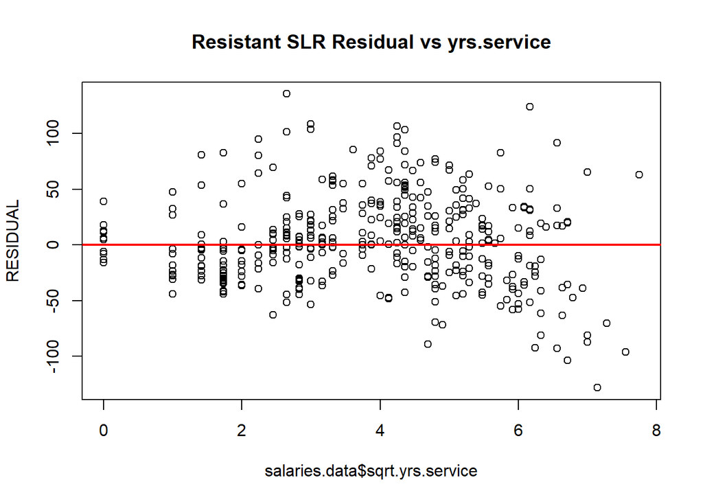

```r
# Residual Analysis
plot(salaries.data$sqrt.yrs.service, RESIDUAL,
     main = 'Resistant SLR Residual vs yrs.service')
abline(h=0, col = "red", lwd=2)
```

```r
# Finding convergence with iterations from 5 to 10
Results <- data.frame(Iteration=NULL, Slope=NULL, Intercept=NULL)
for(iterations in 1:10){
  fit <- rline(sqrt.yrs.service ~ sqrt.salary, salaries.data, iter=iterations)
  Results <- rbind(Results,
                   data.frame(Iteration=iterations,
                              Slope=fit$b, Intercept=fit$a))
}
Results
```

```
##    Iteration   Slope Intercept
## 1          1 0.02481     3.549
## 2          2 0.02571     3.417
## 3          3 0.02569     3.417
## 4          4 0.02569     3.417
## 5          5 0.02569     3.417
## 6          6 0.02569     3.417
## 7          7 0.02569     3.417
## 8          8 0.02569     3.417
## 9          9 0.02569     3.417
## 10        10 0.02569     3.417
```

```r
# Median x value
(xc <- summary.points[[2,1]])
```

```
## [1] 4.243
```

```r
# Build linear model
lm(sqrt.yrs.service ~ I(sqrt.salary - xc), data = salaries.data)
```

```
##
## Call:
## lm(formula = sqrt.yrs.service ~ I(sqrt.salary - xc), data = salaries.data)
##
## Coefficients:
##         (Intercept)  I(sqrt.salary - xc)
##              -1.433                0.016
```

```r
# Create an outlier to see difference
(salaries.data$yrs.service.a <- salaries.data$sqrt.yrs.service)
```

```
##   [1] 4.243 4.000 1.732 6.245 6.403 2.449 4.796 6.708 4.472 4.243 2.828 1.414
##  [13] 1.000 0.000 4.243 1.732 4.472 5.831 4.796 6.000 5.099 5.568 5.477 4.359
##  [25] 2.828 2.828 4.796 1.732 0.000 2.828 2.000 1.414 3.000 1.414 1.414 0.000
##  [37] 4.583 2.000 5.568 3.000 1.414 4.796 5.196 6.164 4.359 3.873 5.292 4.359
##  [49] 5.000 1.000 5.292 3.317 1.732 3.000 3.317 2.236 4.583 2.828 3.000 1.732
##  [61] 2.828 1.414 5.568 3.317 1.732 2.828 3.464 5.568 4.123 6.000 1.414 6.708
##  [73] 4.359 5.831 4.796 1.732 1.732 4.359 1.000 1.414 5.292 4.000 4.472 1.414
##  [85] 4.243 3.742 6.083 1.414 5.000 2.646 2.236 2.646 2.646 6.164 4.472 0.000
##  [97] 3.464 2.646 3.742 5.099 5.000 4.796 2.236 3.742 3.162 5.292 2.828 2.828
## [109] 2.828 5.568 4.000 4.000 1.000 6.083 0.000 3.000 5.385 6.000 1.000 1.732
## [121] 3.742 5.657 4.690 4.690 4.690 7.000 5.099 0.000 5.477 1.414 3.000 7.550
## [133] 2.828 1.000 5.000 4.243 3.742 3.742 2.646 4.243 2.828 3.162 3.317 1.732
## [145] 5.196 5.292 2.000 5.196 5.099 1.732 3.464 2.000 3.000 3.162 0.000 4.583
## [157] 4.243 0.000 2.449 4.000 1.414 4.359 2.646 1.732 0.000 2.828 4.000 4.359
## [169] 2.449 4.243 2.236 4.359 4.899 4.472 2.449 5.000 2.646 3.000 3.742 1.732
```

[output cut: 19 more lines]

```r
(salaries.data$yrs.service.a[331])
```

```
## [1] 7.746
```

```r
(salaries.data$yrs.service.a[331] <- 10) ##?????
```

```
## [1] 10
```

```r
r <- rline(yrs.service.a ~ sqrt.salary, salaries.data, 10)
r[c("a", "b", "xC")]
```

```
## $a
## [1] 3.417
##
## $b
## [1] 0.02569
##
## $xC
## [1] 327.6
```

```r
(slr.a <- lm(salaries.data$yrs.service.a ~ I(sqrt.salary - r$xC), salaries.data))
```

```
##
## Call:
## lm(formula = salaries.data$yrs.service.a ~ I(sqrt.salary - r$xC),
##     data = salaries.data)
##
## Coefficients:
##           (Intercept)  I(sqrt.salary - r$xC)
##                3.7339                 0.0163
```

```r
(slr.a <- lm(yrs.service.a ~ sqrt.salary, salaries.data))
```

```
##
## Call:
## lm(formula = yrs.service.a ~ sqrt.salary, data = salaries.data)
##
## Coefficients:
## (Intercept)  sqrt.salary
##     -1.5976       0.0163
```

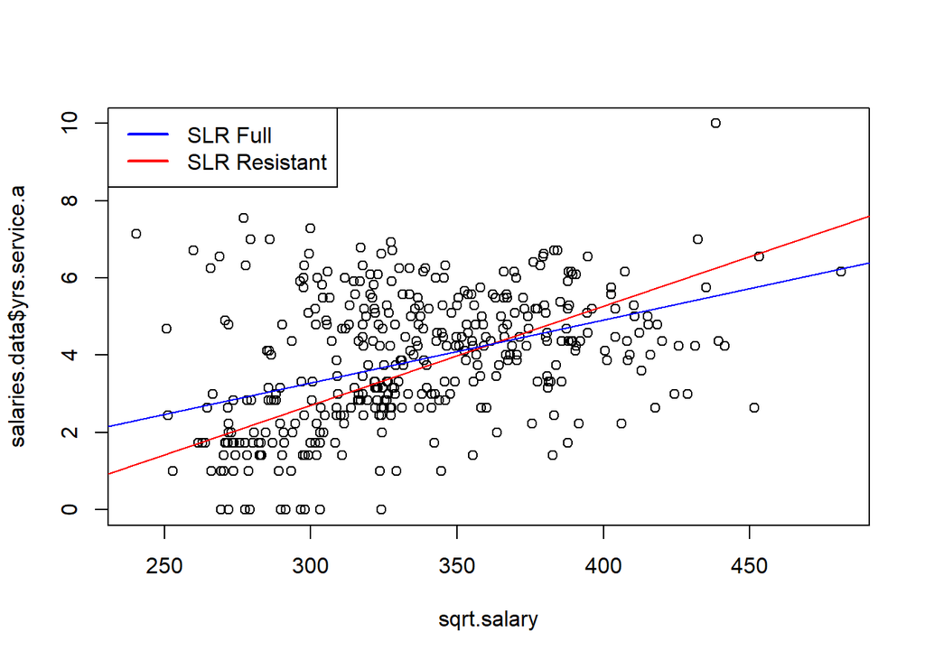

```r
with(salaries.data, plot(sqrt.salary, salaries.data$yrs.service.a))
abline(a = r$a + r$b * -r$xC,
       b = r$b, col = "red")
abline(slr.a, col = "blue")
legend("topleft", legend = c("SLR Full", "SLR Resistant"),
       col = c("blue", "red"), lwd=2)
```

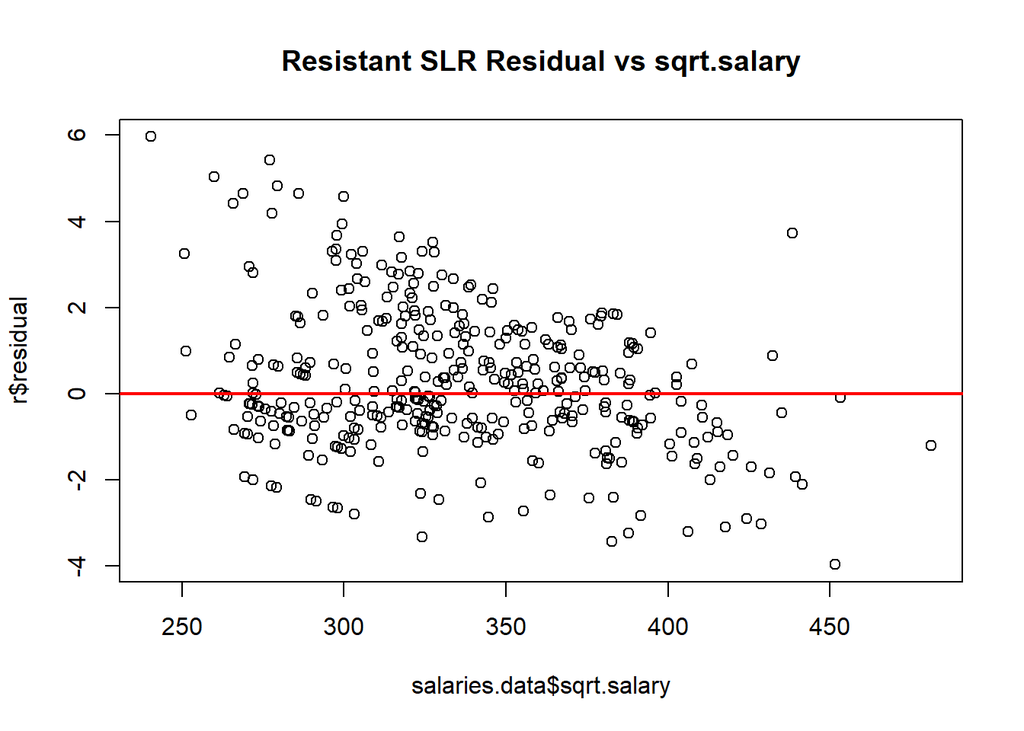

```r
# Resistant v Full Residual Analysis
plot(salaries.data$sqrt.salary, r$residual,
     main = 'Resistant SLR Residual vs sqrt.salary')
abline(h=0, col = "red", lwd=2)
```

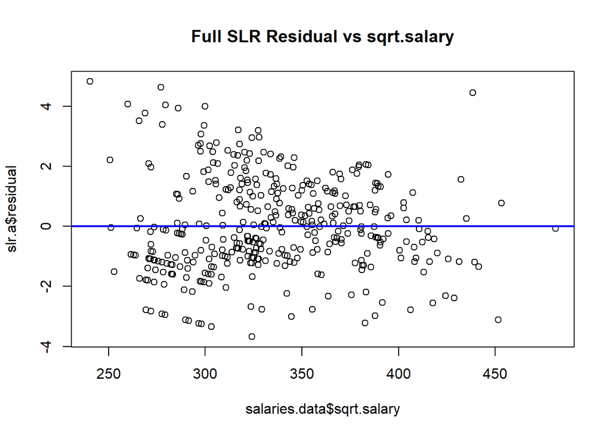

```r
plot(salaries.data$sqrt.salary, slr.a$residual,
     main = 'Full SLR Residual vs sqrt.salary')
abline(h=0, col = "blue", lwd=2)
```

>> Looking at these above graphs we can see how the resistant lines maintains its positiom even after after changing row 331 to the value 10.Regardless The graph tries its best yo represent all the positions but some are just distant such as those with a residual of 6.